# Lab2

Kaden DuBois

2024-08-28

# Tasks

## Task 1

### Get working directory

```r
getwd()
```

```
## [1] "C:/Users/Kaden/Desktop/MATH4753KadenDuB/Labs/Lab2"
```

## Task 2

### Read the EPAGAS.csv file into R

```r
epagas <- read.csv('EPAGAS.csv')
```

### Obtain the first 6 entries of Epagas

```r
head(epagas)
```

```
##    MPG
## 1 36.3
## 2 41.0
## 3 36.9
## 4 37.1
## 5 44.9
## 6 36.8
```

## Task 3

### Make the object mpg, a miles per galon vector

```r
mpg=epagas$MPG
```

### Transform the mpg to z

```r
z=(mpg-mean(mpg))/sd(mpg)
```

Verify that the mean value of z is 0

```r
mean(z)
```

```
## [1] 1.058709e-16
```

Verify that the standard deviation of z squared is 1

```r
sd(z)^2
```

```
## [1] 1
```

### Find the values of mpg that are possible outliers using z

```r
mpg[abs(z)>=2 & abs(z)<=3]
```

```
## [1] 30.0 42.1 31.8
```

### Find the values of mpg that are defined as outliers

```r
mpg[abs(z)>3]
```

```
## [1] 44.9
```

### Construct a dotplot of mpg with colors

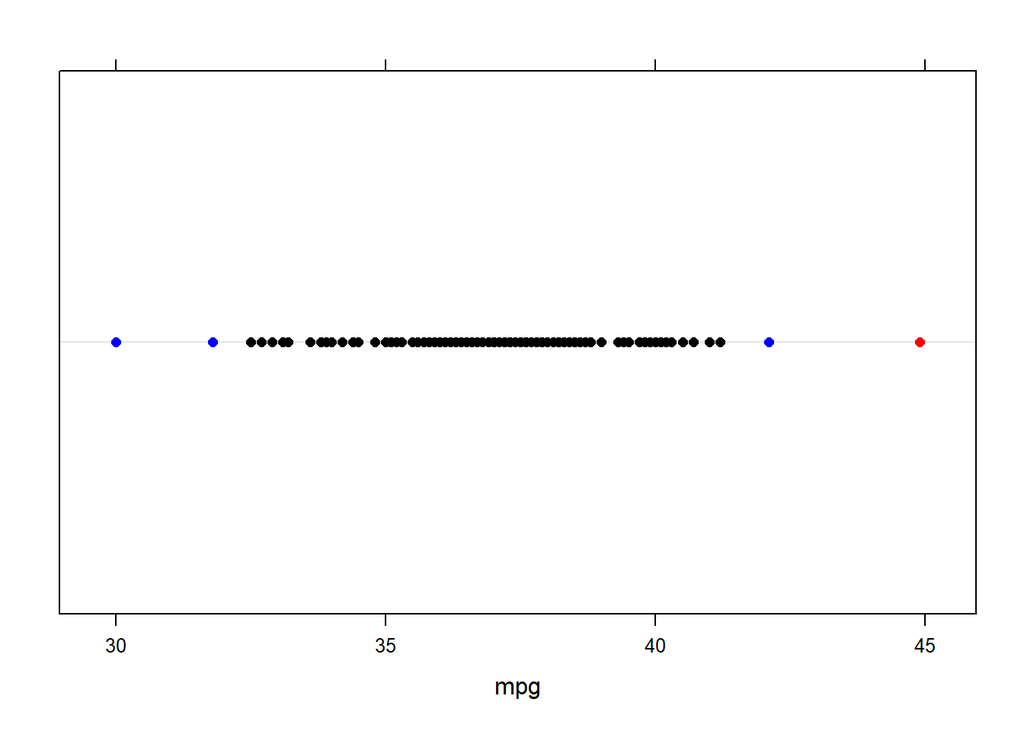

```r
library(lattice)
dotcol = ifelse(abs(z)>3, "Red",
          ifelse(abs(z)>=2 & abs(z)<=3,"Blue",
            "Black"))
dotplot(mpg, col=dotcol)
```

## Task 4

### Make a boxplot of the MPG varaiable meeting specifications

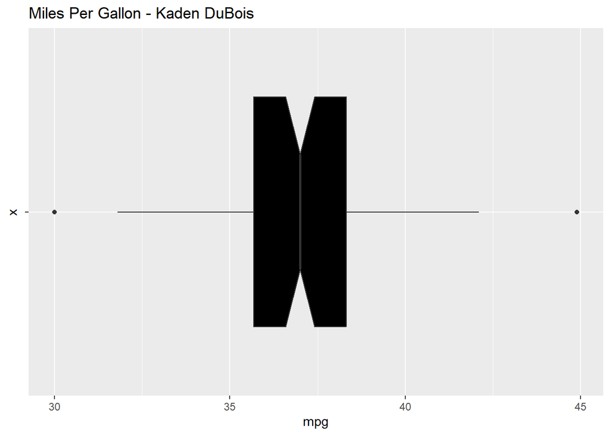

```r
library(ggplot2)
ggplot(epagas, aes(x='',y=mpg)) +
  geom_boxplot(fill='Black', notch=TRUE) + coord_flip() + ggtitle("Miles Per Gallon - Kaden DuBois")
```

### Use Chebyshev’s theorem to predict the proportion of data within 2 standard deviations of the mean

3/4 of the data should be within 2 standard deviations of the mean

### Calculate the exact proportion within 2 standard deviation of the mean

```r
length(mpg[abs(z)<2])/length(mpg)
```

```
## [1] 0.96
```

### Does Chebyshev agree with the data?

Chebyshev’s theorem does not agree with the data, it provides a prediction much lower than the actual value.

### Use the emperical rule to predict the proportion of data within 2 standard deviations of the mean

The emperical rule states that approximately 95% of the data should be within 2 standard deviations of the mean.

### How well does it correspond?

The emperical rule corresponds almost exactly to the actual value that is calculated.

### Is the emperical rule valid in this case?

We can use a histogram to visualize the distribution of the data.

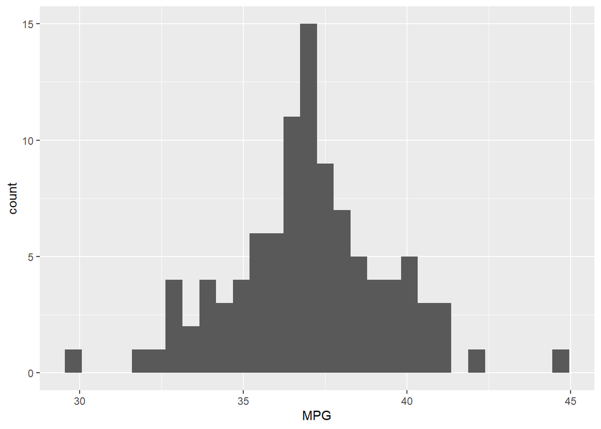

```r
ggplot(epagas,aes(x=MPG)) + geom_histogram()
```

Looking at this histogram, we can see that the data is approximately symmetrical and mound shaped. Because of this distribution, the emperical rule is valid to use in this case.